# Los Angeles Demographics Lab

Myron Bañez | CPLN 6200: Techniques of Urban Economic Development

# Introduction

This document serves as a demographic profile of Los Angeles County using 2010 to 2020 data from the American Community Survey. The regional demographic profile is useful in understanding the characteristics that makes the region unique. Moving forward, this knowledge of the regional demographic profile serves as a foundation in conducting further analysis on the economic profile for Los Angeles County

```r
knitr::opts_chunk$set(echo = TRUE)

library(tidycensus)
library(sf)
library(tidyverse)
library(sf)
library(lubridate)
library(tigris)
library(gganimate)
library(riem)
library(gridExtra)
library(knitr)
library(kableExtra)
library(mapview)
library(tidycensus)
library(ggcorrplot)
library(RColorBrewer)
library(stargazer)
library(ggplot2)
theme_set(theme_bw())

if(!require(pacman)){install.packages("pacman"); library(pacman)}
p_load(tidyverse, here, janitor)

options(scipen=999)

palette9 <- c("#fff600", "#ffdd00", "#fdcc0d", "#e6b70f", "#8649d1", "#7225d0", "#6813d0", "#630ad0", "#5000b8")

palette24 <- c("#dbaf00","#fdc500","#ffd500","#ffee32","#cea7ee","#b67be6","#9d4edd","#72369d","#461e5c","#2b2d42", "#ffcdb2","#ffb4a2","#e5989b","#b5838d", "#d9ed92","#b5e48c","#99d98c","#76c893","#52b69a","#34a0a4","#168aad","#1a759f","#1e6091","#184e77")
```

```r
la_estimates <- get_estimates(geography = "cbsa", product = "population", time_series = TRUE, output = "tidy")
la_comps <- get_estimates(geography = "cbsa", product = "components", time_series = TRUE, output = "tidy")

la_estimates <- clean_names(la_estimates, "snake")
la_comps <- clean_names(la_comps, "snake")

la_estimates <- la_estimates %>%
filter(variable == "POP" & geoid == "31080")
la_comps <- la_comps %>%
  filter(geoid == "31080")
```

# High Level Demographics

The follow section looks at demographic estimates including: population, natural increase, and migration for Los Angeles County, providing high level information regarding the features that drive the region towards growth or decline.

Note: The date columns ranging from 1-12 or 1-10 represent the years 2010-2021 and 2010-2019 respectively.

## Population

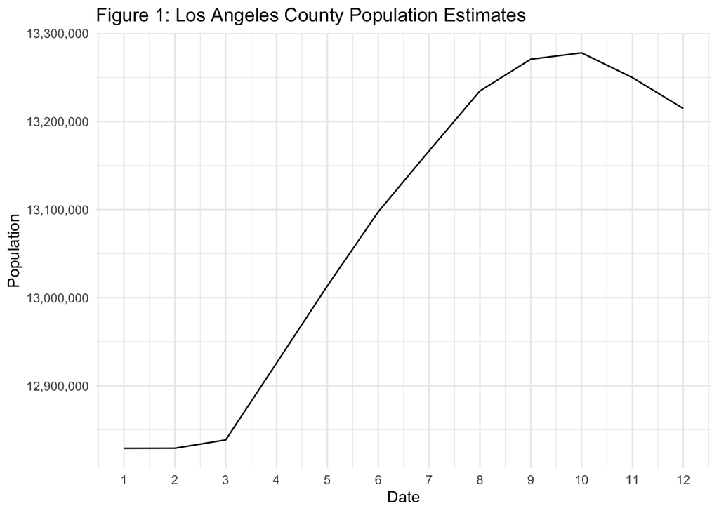

```r
pop_plot1 <- ggplot(la_estimates, aes(x = date, y = value)) +
  geom_line() +
  theme_minimal() +
  labs(title = "Figure 1: Los Angeles County Population Estimates", x = "Date", y = "Population") +
  scale_x_continuous(breaks = c("1":"12")) +
  scale_y_continuous(labels = scales::comma)
pop_plot1
```